# CHPS Longitudinal Report

# What Works Comprehensive Hazing Prevention Survey (CHPS) Report for Virginia Polytechnic Institute and State University

This report analyzes survey responses from the What Works Comprehensive Hazing Prevention Survey (CHPS). Data collection began in 2025, and the dataset contains 1,000 responses from fraternity and sorority members at Virginia Polytechnic Institute and State University.

Total Survey Responses by Year

| Year | Responses |
| --- | --- |
| 2025 | 933 |
| 2026 | 67 |

## Campus Program Impact Analysis

### Baseline Program Performance

The table below shows the percentage of respondents who reported a positive impact during the first year (2025). This represents the “starting point” for each program.

Baseline % Comparison Across All Impact Categories

| Program | Changed attitude | More likely to intervene | More likely to report |
| --- | --- | --- | --- |
| Bystander training | 22.8 | 26.9 | 25.8 |
| Leadership retreat | 15.8 | 14.6 | 15.8 |
| Online information/workshop | 29.3 | 35.7 | 34.4 |
| Peer-led workshop | 24.8 | 31.1 | 29.6 |
| Professionally-led workshop | 28.5 | 31.8 | 32.4 |
| Speaker series | 30.9 | 33.5 | 32.0 |

### Program Impact: Annual Momentum & Total Growth

This heatmap shows the year-over-year change alongside the total growth since the baseline.

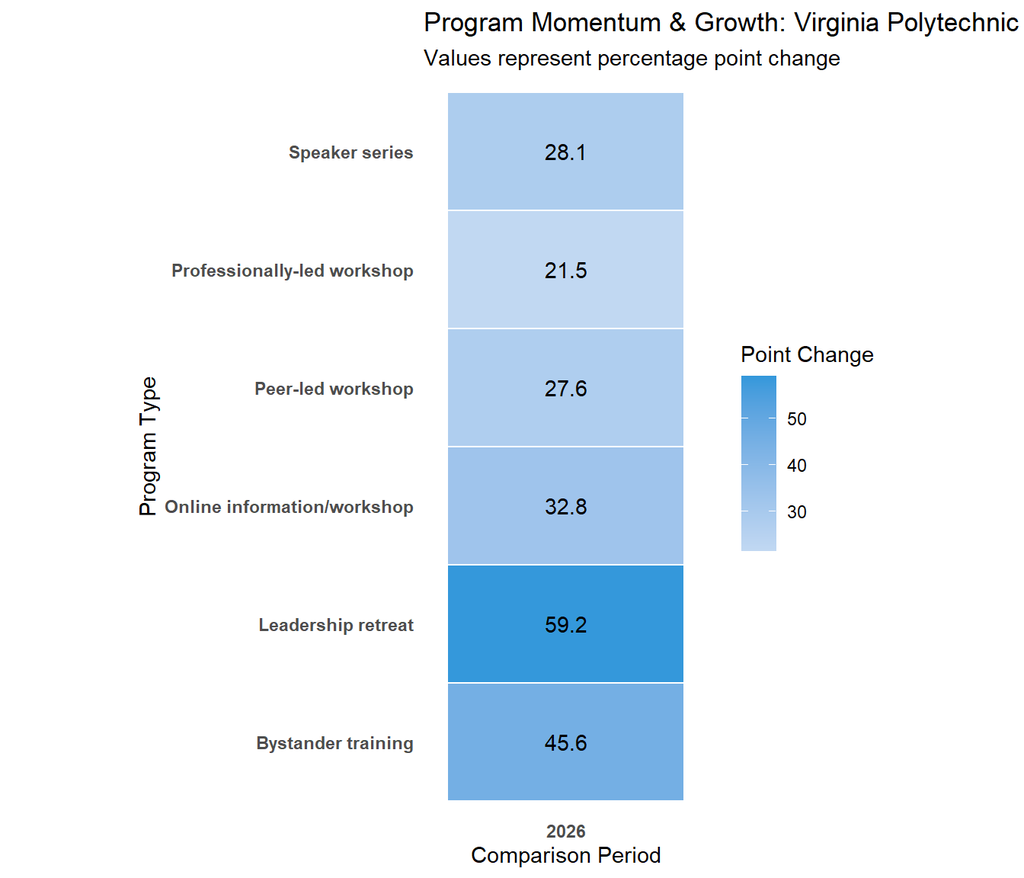